# EP01-respuesta-equipo-7

Alfonso Palacios y Nicolás Sarabia

2025-08-21

# Estadística descriptiva con R

## Pregunta 7

**¿Tiene relación el ingreso de las mujeres de la RM con el riqueza del municipio donde habita?**

```r
# Leer archivo
data <- read.csv2("EP01 Datos Casen 2017.csv")
```

Para verificar esta relación se propone la realización de un modelo de regresión lineal simple, y posteriormente analizar el coeficiente de determinación para verificar la proporción de varianza según la cual el ingreso total (ytot) de las mujeres de la RM es descrito por la riqueza de la comuna en donde habitan (ing.comuna)

Para responder la pregunta planteada, se determinaron las variables a utilizar:

- sexo y region: Para filtrar (Categoricas nominales)
- ing.comuna (ing.comuna): Variable independiente (Categórica ordinal)
- ingreso total (ytot): Variable dependiente (Cuantitativa continua)

En primera instancia, se filtra el dataset (data) utilizando las variables de sexo y región, para guardar las mujeres de la región metropolitana.

```r
# Filtrar dataset por mujeres
library(dplyr)
mujeres <- data %>%
  filter(sexo == "Mujer", region == "Región Metropolitana de Santiago")
```

Posterior a ello, se aplica un modelo de regresión lineal, donde la variable dependiente es el ingreso total y la variable independiente es el ranking del ingreso de la comuna.

```r
# Buscar relación entre variables ingreso total (ytot) y los ingresos de la comuna (ing.comuna)
reglin <- lm(formula = ytot ~ ing.comuna, data=mujeres)
summary(reglin)
```

```
##
## Call:
## lm(formula = ytot ~ ing.comuna, data = mujeres)
##
## Residuals:
##      Min       1Q   Median       3Q      Max
##  -809022  -354938  -133658   123014 63481813
##
## Coefficients:
##             Estimate Std. Error t value Pr(>|t|)
## (Intercept)   5150.5    16698.5   0.308    0.758
## ing.comuna   15475.1      485.8  31.855   <2e-16 ***
## ---
## Signif. codes:  0 '***' 0.001 '**' 0.01 '*' 0.05 '.' 0.1 ' ' 1
##
## Residual standard error: 884300 on 14425 degrees of freedom
## Multiple R-squared:  0.06572,    Adjusted R-squared:  0.06566
## F-statistic:  1015 on 1 and 14425 DF,  p-value: < 2.2e-16
```

Finalmente, se grafican y analizan los resultados obtenidos

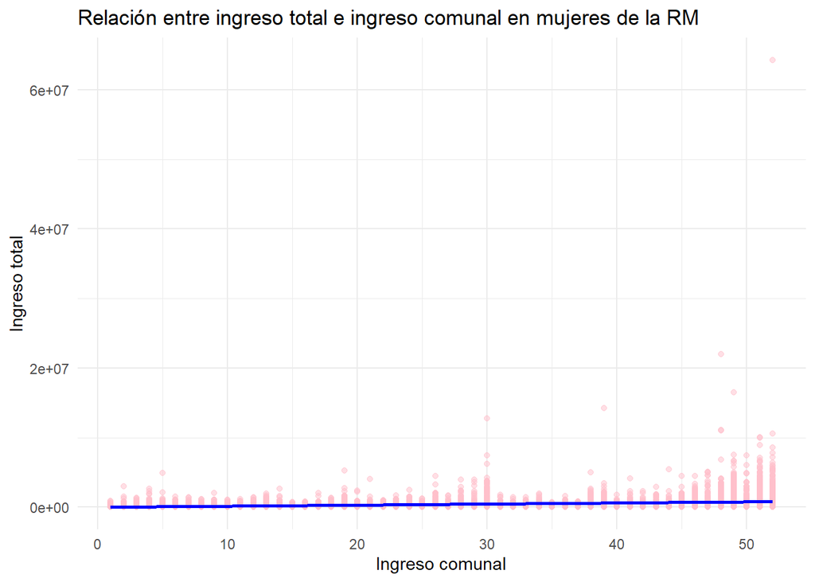

```r
library(ggplot2)

ggplot(mujeres, aes(x=ing.comuna, y=ytot)) +
  geom_point(alpha=0.5, color="pink") +
  geom_smooth(method="lm", se=TRUE, color="blue") +
  labs(title="Relación entre ingreso total e ingreso comunal en mujeres de la RM",
       x="Ingreso comunal", y="Ingreso total") + theme_minimal()
```

El modelo ajustado muestra una relación que es estadísticamente significativa entre el ingreso total de las mujeres de la RM y el ingreso del municipio en donde habitan. Estas presentan una relación directamente proporcional, siendo el ingreso de la comuna un predictor significativo para el ingreso total al 95% de confianza. El p-valor del modelo es menor a 2.2e-16, algo que sugiere que el modelo es globalmente significativo, y por ende sus resultados son confiables. Finalmente, el valor del coeficiente de determinación (R^2) indica que aproximadamente el 6,6% de la variabilidad en el ingreso total es explicado por el ingreso de la comuna, lo cual sugiere que existe una correlación lineal muy baja en el estudio hecho, lo cual puede ser corroborado realizando un zoom al gráfico hecho.

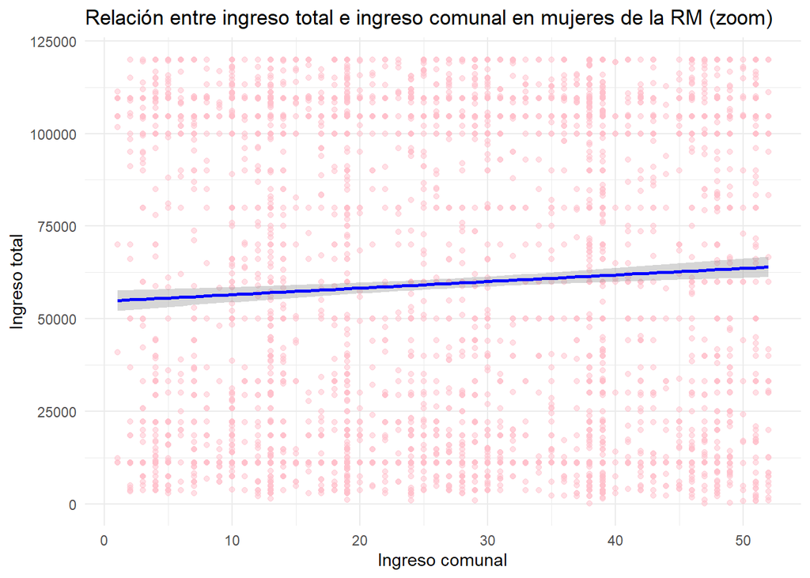

```r
library(ggplot2)

ggplot(mujeres, aes(x=ing.comuna, y=ytot)) +
  ylim(c(0,120000)) +
  geom_point(alpha=0.5, color="pink") +
  geom_smooth(method="lm", se=TRUE, color="blue") +
  labs(title="Relación entre ingreso total e ingreso comunal en mujeres de la RM (zoom)",
       x="Ingreso comunal", y="Ingreso total") + theme_minimal()
```

En conclusión, el ingreso de las mujeres de la RM con la riqueza del municipio donde habita poseen una relación que se puede explicar levemente mediante un modelo de regresión lineal, siendo el 6,6% de la variabilidad en el ingreso total explicado por el ingreso de la comuna.